# Analysis of First Pass Regressions Out

## With Fit

```r
m_con_f_1 <- mixed(Consequent ~ Fit + (Fit|P.s) + (Fit| Item), drp_r, family = binomial, method = "LRT", progress = FALSE)
```

```
Contrasts set to contr.sum for the following variables: Fit, P.s, Item
```

```r
summary(m_con_f_1)
```

```
Generalized linear mixed model fit by maximum likelihood (Laplace Approximation) ['glmerMod']
 Family: binomial  ( logit )
Formula: Consequent ~ Fit + (Fit | P.s) + (Fit | Item)
   Data: drp_r

     AIC      BIC   logLik deviance df.resid
   174.4    206.5    -79.2    158.4      400

Scaled residuals:
    Min      1Q  Median      3Q     Max
-0.3675 -0.2344 -0.1924 -0.1764  4.9344

Random effects:
 Groups Name        Variance Std.Dev. Corr
 P.s    (Intercept) 0.15819  0.3977
        Fit1        0.02229  0.1493   -1.00
 Item   (Intercept) 0.37929  0.6159
        Fit1        0.02434  0.1560   -1.00
Number of obs: 408, groups:  P.s, 24; Item, 17

Fixed effects:
            Estimate Std. Error z value Pr(>|z|)
(Intercept) -3.21913    0.41287  -7.797 6.34e-15 ***
Fit1         0.01989    0.40732   0.049    0.961
---
Signif. codes:  0 *** 0.001 ** 0.01 * 0.05 . 0.1   1

Correlation of Fixed Effects:
     (Intr)
Fit1 -0.325
```

The correlations between the random effects parameters are at the boundary of the parameter space, consequently we remove those.

```r
m_con_f_2 <- mixed(Consequent ~ Fit + (Fit||P.s) + (Fit|| Item), drp_r, family = binomial, method = "LRT", progress = FALSE, expand_re = TRUE)
```

```
Contrasts set to contr.sum for the following variables: Fit, P.s, Item
```

```r
summary(m_con_f_2)
```

```
Generalized linear mixed model fit by maximum likelihood (Laplace Approximation) ['glmerMod']
 Family: binomial  ( logit )
Formula: Consequent ~ Fit + (1 + re1.Fit1 || P.s) + (1 + re2.Fit1 || Item)
   Data: drp_r

     AIC      BIC   logLik deviance df.resid
   170.5    194.6    -79.3    158.5      402

Scaled residuals:
    Min      1Q  Median      3Q     Max
-0.3238 -0.2334 -0.1958 -0.1764  4.7743

Random effects:
 Groups Name        Variance  Std.Dev.
 P.s    (Intercept) 1.497e-01 0.3869607
 P.s.1  re1.Fit1    1.844e-08 0.0001358
 Item   (Intercept) 3.781e-01 0.6149024
 Item.1 re2.Fit1    0.000e+00 0.0000000
Number of obs: 408, groups:  P.s, 24; Item, 17

Fixed effects:
            Estimate Std. Error z value Pr(>|z|)
(Intercept)  -3.1995     0.4144  -7.720 1.16e-14 ***
Fit1         -0.1090     0.2332  -0.467     0.64
---
Signif. codes:  0 *** 0.001 ** 0.01 * 0.05 . 0.1   1

Correlation of Fixed Effects:
     (Intr)
Fit1 0.069
```

Now the by-participant and by-item random slopes for `Fit` are virtually zero, so we consequently refit the model without these parameters, we also try all available optimizer to see if this helps.

```r
m_con_f_3 <- mixed(Consequent ~ Fit + (1|P.s) + (1| Item), drp_r, family = binomial, method = "LRT", progress = FALSE, expand_re = FALSE, all_fit = TRUE)
```

```
Contrasts set to contr.sum for the following variables: Fit, P.s, Item
```

```r
summary(m_con_f_3)
```

```
Generalized linear mixed model fit by maximum likelihood (Laplace Approximation) ['glmerMod']
 Family: binomial  ( logit )
Formula: Consequent ~ Fit + (1 | P.s) + (1 | Item)
   Data: drp_r
Control: ctrl

     AIC      BIC   logLik deviance df.resid
   166.5    182.6    -79.3    158.5      404

Scaled residuals:
    Min      1Q  Median      3Q     Max
-0.3238 -0.2334 -0.1958 -0.1764  4.7743

Random effects:
 Groups Name        Variance Std.Dev.
 P.s    (Intercept) 0.1497   0.3870
 Item   (Intercept) 0.3781   0.6149
Number of obs: 408, groups:  P.s, 24; Item, 17

Fixed effects:
            Estimate Std. Error z value Pr(>|z|)
(Intercept)  -3.1995     0.4144  -7.720 1.16e-14 ***
Fit1         -0.1090     0.2332  -0.467     0.64
---
Signif. codes:  0 *** 0.001 ** 0.01 * 0.05 . 0.1   1

Correlation of Fixed Effects:
     (Intr)
Fit1 0.069
```

Overall, the final model seems to provide the best account (i.e., is the optimal model).

```r
anova(m_con_f_1, m_con_f_2, m_con_f_3)
```

```
Data: drp_r
Models:
m_con_f_3: Consequent ~ Fit + (1 | P.s) + (1 | Item)
m_con_f_2: Consequent ~ Fit + (1 + re1.Fit1 || P.s) + (1 + re2.Fit1 || Item)
m_con_f_1: Consequent ~ Fit + (Fit | P.s) + (Fit | Item)
          Df    AIC    BIC  logLik deviance  Chisq Chi Df Pr(>Chisq)
m_con_f_3  4 166.52 182.57 -79.261   158.52
m_con_f_2  6 170.52 194.59 -79.261   158.52 0.0000      2     1.0000
m_con_f_1  8 174.39 206.48 -79.194   158.39 0.1327      2     0.9358
```

We also perform some graphical model fit tests (using `DHARMa`, see: https://cran.r-project.org/web/packages/DHARMa/vignettes/DHARMa.html) which suggest the model is without large problems (i.e., for the QQ-plot the residuals are on the main diagonal and for the residuals versus predicted the red lines are straight and at .25, .5 and .75).

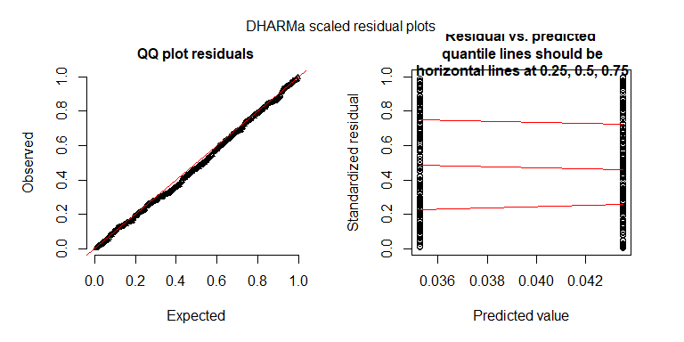

```r
sim_m_con_f_3 <- simulateResiduals(fittedModel = m_con_f_3$full_model, n = 250)
plotSimulatedResiduals(sim_m_con_f_3)
```

```r
nice(m_con_f_1)
```

```
Mixed Model Anova Table (Type 3 tests, LRT-method)

Model: Consequent ~ Fit + (Fit | P.s) + (Fit | Item)
Data: drp_r
Df full model: 8
  Effect df Chisq p.value
1    Fit  1  0.00     .96
---
Signif. codes:  0 *** 0.001 ** 0.01 * 0.05 + 0.1   1
```

```r
nice(m_con_f_3)
```

```
Mixed Model Anova Table (Type 3 tests, LRT-method)

Model: Consequent ~ Fit + (1 | P.s) + (1 | Item)
Data: drp_r
Df full model: 4
  Effect df Chisq p.value
1    Fit  1  0.22     .64
---
Signif. codes:  0 *** 0.001 ** 0.01 * 0.05 + 0.1   1
```

```r
m_con_a_1 <- mixed(Consequent ~ acc_z + (acc_z|P.s) + (Fit| Item), drp_r, family = binomial, method = "LRT", progress = FALSE)
```

```
Contrasts set to contr.sum for the following variables: P.s, Fit, Item
Model failed to converge with max|grad| = 0.0133446 (tol = 0.001, component 1)Model failed to converge with max|grad| = 0.00115218 (tol = 0.001, component 1)
```

```r
summary(m_con_a_1)
```

```
Generalized linear mixed model fit by maximum likelihood (Laplace Approximation) ['glmerMod']
 Family: binomial  ( logit )
Formula: Consequent ~ acc_z + (acc_z | P.s) + (Fit | Item)
   Data: drp_r

     AIC      BIC   logLik deviance df.resid
   174.0    206.1    -79.0    158.0      400

Scaled residuals:
    Min      1Q  Median      3Q     Max
-0.3578 -0.2312 -0.1937 -0.1653  4.7398

Random effects:
 Groups Name        Variance Std.Dev. Corr
 P.s    (Intercept) 0.199553 0.44671
        acc_z       0.032830 0.18119  -1.00
 Item   (Intercept) 0.394033 0.62772
        Fit1        0.007556 0.08692  -1.00
Number of obs: 408, groups:  P.s, 24; Item, 17

Fixed effects:
            Estimate Std. Error z value Pr(>|z|)
(Intercept) -3.24560    0.41063  -7.904  2.7e-15 ***
acc_z       -0.06812    0.34446  -0.198    0.843
---
Signif. codes:  0 *** 0.001 ** 0.01 * 0.05 . 0.1   1

Correlation of Fixed Effects:
      (Intr)
acc_z -0.141
convergence code: 0
Model failed to converge with max|grad| = 0.0133446 (tol = 0.001, component 1)
```

We see a suspcisouly high correlations between for both random effect grouping factors, consequently we remove those.

```r
m_con_a_2 <- mixed(Consequent ~ acc_z + (acc_z||P.s) + (Fit|| Item), drp_r, family = binomial, method = "LRT", progress = FALSE, expand_re = TRUE, all_fit = TRUE)
```

```
Contrasts set to contr.sum for the following variables: P.s, Fit, Item
```

```r
summary(m_con_a_2)
```

```
Generalized linear mixed model fit by maximum likelihood (Laplace Approximation) ['glmerMod']
 Family: binomial  ( logit )
Formula: Consequent ~ acc_z + (1 + re1.acc_z || P.s) + (1 + re2.Fit1 ||      Item)
   Data: drp_r
Control: ctrl

     AIC      BIC   logLik deviance df.resid
   170.2    194.3    -79.1    158.2      402

Scaled residuals:
    Min      1Q  Median      3Q     Max
-0.3185 -0.2341 -0.1973 -0.1717  4.7732

Random effects:
 Groups Name        Variance Std.Dev.
 P.s    (Intercept) 0.1524   0.3904
 P.s.1  re1.acc_z   0.0000   0.0000
 Item   (Intercept) 0.3942   0.6278
 Item.1 re2.Fit1    0.0000   0.0000
Number of obs: 408, groups:  P.s, 24; Item, 17

Fixed effects:
            Estimate Std. Error z value Pr(>|z|)
(Intercept)  -3.2127     0.4180  -7.686 1.52e-14 ***
acc_z        -0.1723     0.2432  -0.708    0.479
---
Signif. codes:  0 *** 0.001 ** 0.01 * 0.05 . 0.1   1

Correlation of Fixed Effects:
      (Intr)
acc_z 0.127
```

Given the small estimate of the by-participant random slope we remove it.

```r
m_con_a_3 <- mixed(Consequent ~ acc_z + (1|P.s) + (1| Item), drp_r, family = binomial, method = "LRT", progress = FALSE, expand_re = TRUE, all_fit = TRUE)
```

```
Contrasts set to contr.sum for the following variables: P.s, Item
```

```r
summary(m_con_a_3)
```

```
Generalized linear mixed model fit by maximum likelihood (Laplace Approximation) ['glmerMod']
 Family: binomial  ( logit )
Formula: Consequent ~ acc_z + (1 | P.s) + (1 | Item)
   Data: drp_r
Control: ctrl

     AIC      BIC   logLik deviance df.resid
   166.2    182.3    -79.1    158.2      404

Scaled residuals:
    Min      1Q  Median      3Q     Max
-0.3185 -0.2341 -0.1973 -0.1717  4.7732

Random effects:
 Groups Name        Variance Std.Dev.
 P.s    (Intercept) 0.1524   0.3904
 Item   (Intercept) 0.3942   0.6278
Number of obs: 408, groups:  P.s, 24; Item, 17

Fixed effects:
            Estimate Std. Error z value Pr(>|z|)
(Intercept)  -3.2127     0.4180  -7.686 1.52e-14 ***
acc_z        -0.1723     0.2432  -0.708    0.479
---
Signif. codes:  0 *** 0.001 ** 0.01 * 0.05 . 0.1   1

Correlation of Fixed Effects:
      (Intr)
acc_z 0.127
```

```r
anova(m_con_a_1, m_con_a_2, m_con_a_3)
```

```
Data: drp_r
Models:
m_con_a_3: Consequent ~ acc_z + (1 | P.s) + (1 | Item)
m_con_a_2: Consequent ~ acc_z + (1 + re1.acc_z || P.s) + (1 + re2.Fit1 ||
m_con_a_2:     Item)
m_con_a_1: Consequent ~ acc_z + (acc_z | P.s) + (Fit | Item)
          Df    AIC    BIC  logLik deviance  Chisq Chi Df Pr(>Chisq)
m_con_a_3  4 166.23 182.28 -79.117   158.23
m_con_a_2  6 170.23 194.30 -79.117   158.23 0.0000      2     1.0000
m_con_a_1  8 173.98 206.07 -78.989   157.98 0.2553      2     0.8802
```

Again, the reduced model seems to be the optimal model. Consequently we also inspect the residuals of this model. Overall this looks very reasonable despite the fitted versus residuals plot.

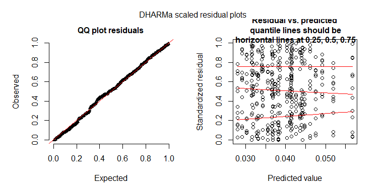

```r
sim_m_con_a_3 <- simulateResiduals(fittedModel = m_con_a_3$full_model, n = 500)
plotSimulatedResiduals(sim_m_con_a_3)
```

Interestingly, neither model shows a significant effect of `Accepts` (z-transformed to `acc_z`).

```r
nice(m_con_a_1)
```

```
Mixed Model Anova Table (Type 3 tests, LRT-method)

Model: Consequent ~ acc_z + (acc_z | P.s) + (Fit | Item)
Data: drp_r
Df full model: 8
  Effect df Chisq p.value
1  acc_z  1  0.04     .84
---
Signif. codes:  0 *** 0.001 ** 0.01 * 0.05 + 0.1   1
```

```r
nice(m_con_a_3)
```

```
Mixed Model Anova Table (Type 3 tests, LRT-method)

Model: Consequent ~ acc_z + (1 | P.s) + (1 | Item)
Data: drp_r
Df full model: 4
  Effect df Chisq p.value
1  acc_z  1  0.51     .48
---
Signif. codes:  0 *** 0.001 ** 0.01 * 0.05 + 0.1   1
```

# Spillover

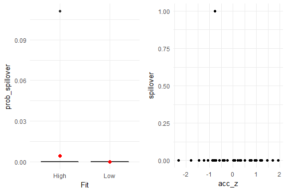

```r
p_obs_acc <- ggplot(data = drp_r, aes(x = acc_z, y = spillover)) +
  geom_point()
p_obs_fit <- ggplot(agg, aes(x = Fit, y = prob_spillover)) +
  geom_boxplot() +
   stat_summary(fun.y = "mean", colour = "red", size = 2, geom = "point")
grid.arrange(p_obs_fit, p_obs_acc, ncol = 2)
```

Given there is only one spillover event this obviates all statistical analyses.